# CSC 453

Spring 2026 - Day 3

## Admin

- Lab 1 due Thursday, 11:59 PM
- Quiz 2 due Monday, 11:59 PM
- Assignment 1 due April 15

# Dual-mode / Syscalls

## Questions to consider

- How do we ensure that a user process doesn’t harm others?
- How do system calls work? How do they relate to wrapper libraries like `glibc`?

## Interrupts and traps

- How does the OS regain control of the CPU when a process is running?
- Two mechanisms that transfer control to the kernel:
  - Hardware interrupts: asynchronous, generated by devices
    - Timer, disk I/O completion, keyboard, network
    - CPU checks for pending interrupts between instructions
  - Software traps: synchronous, generated by the running program
    - System calls (intentional)
    - Exceptions: divide-by-zero, page fault, illegal instruction (unintentional)
- Both use the same basic mechanism: save state, jump to a kernel handler via an interrupt vector table

## Interrupts and traps (cont’d)

[figure not shown]

## Why this matters

- Without hardware interrupts, a misbehaving process could monopolize the CPU forever
- The timer interrupt is the foundation of preemptive scheduling (we’ll talk about scheduling later)
  - Hardware timer fires periodically (e.g., every 1-10 ms)
  - Forces a trap into kernel mode regardless of what the process is doing
  - Kernel’s scheduler decides: resume this process or switch to another?
- This is the answer to: “if the process has the CPU, who stops it?”
  - The hardware stops it

## Dual-mode operation

- Dual-mode operation allows OS to protect itself and components
  - User mode and kernel mode
- Mode bit provided/enforced by hardware
  - Provides ability to distinguish when system is running user code or kernel code.
  - When a user is running → mode bit is “user”
  - When kernel code is executing → mode bit is “kernel”
- System call changes mode to kernel, return from call resets it to user
- Some instructions are only executable in kernel mode

## System calls

- The OS offers a number of services. How do we (applications) interface with them?
  - We don’t want to deal with the details, just the abstraction
  - The OS has ultimate control over these operations
- System calls are the “language” of communication with the OS
- Standards
  - Win32 (MS)
  - POSIX (nearly all Unix-based systems)

## System calls (cont’d)

- We call into the library wrapper (e.g., `glibc`) which places arguments into registers
- Each system call has a special number that identifies it to the kernel
- Executes a TRAP instruction (switch to kernel mode)
- A logical separation of memory space
- Kernel’s system call handler is invoked, once done (but may block) may be returned to the process

## System calls (cont’d)

- Table defined in the kernel: [https://github.com/torvalds/linux/blob/master/arch/x86/entry/ syscalls/syscall_32.tbl](https://github.com/torvalds/linux/blob/master/arch/x86/entry/syscalls/syscall_32.tbl)
  - Note that system call tables can differ between architectures
- You can run using the table values themselves using the `syscall()` wrapper
  - Q: why does `syscall()` exist?
  - If you’re interested… There are debates https://lwn.net/Articles/771441/

What isn’t clear?

Comments? Thoughts?

# Process basics

## Questions to consider

- What do processes contain?
- How does the OS run multiple processes at the same time?
- How are processes laid out in memory?
- How does the OS store information about each process?

## Processes

- Most fundamental OS abstraction
  - Processes organize information about other abstractions and represent a single thing the computer is “doing”
- When you run an executable program (passive), the OS creates a process == a running program (active)
- One program can be multiple processes

## Process organization

- Unlike threads, address spaces and files, processes are not tied to a hardware component. Instead, they contain other abstractions
- Processes contain:
  - one or more threads,
  - an address space, and
  - zero or more open file handles representing files

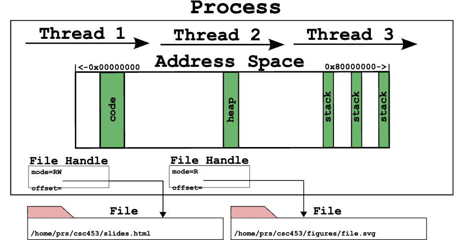

## Multiprogramming

- Processes are the core abstraction that allows for multiprogramming: the illusion of concurrency
- OS timeshares CPU across multiple processes: virtualizes CPU
- OS has a CPU scheduler that picks one of the many active processes to execute on a CPU
- Policy:
  - which process to run
- Mechanism:
  - how to context switch between processes

## Process’s view of the world

- Own memory with consistent addressing (divorced from physical addressing)
- It has exclusivity over the CPU: It doesn’t have to worry about scheduling
- Conversely, it doesn’t know when it will be scheduled, so real time events require special handling
- Has some identity: `pid`, `gid`, `uid`
- Has a set of services available to it via the OS
  - Data (via file system)
  - Communication (sockets, IPC)
  - More resources (e.g., memory)

## Process memory layout

- Text segment: machine instructions; shareable between identical processes; read-only
- Data segment: for initialized data; e.g., `int count = 99;`
- BSS (block started by symbol) segment: uninitialized data; e.g., `int sum[10];`
- Heap: dynamic memory allocation
- Stack: initial arguments and environment; stack frames

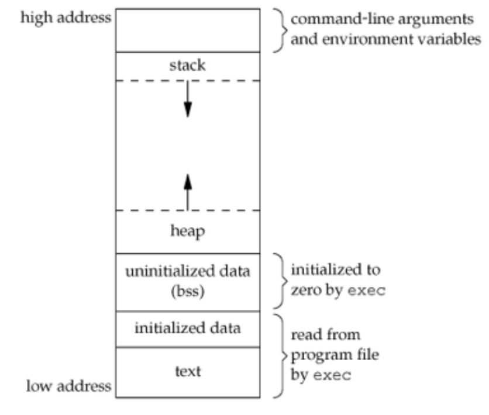

## OS’s view of the (process) world

- Data for each process is held in a data structure known as a Process Control Block
- Partitioned memory:
  - dedicated & shared address space
  - perhaps non-contiguous
- Process table holds PCBs

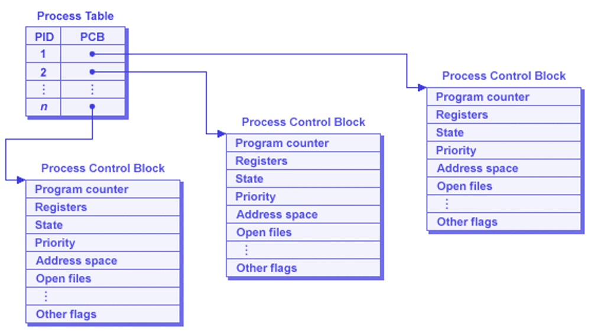

What isn’t clear?

Comments? Thoughts?

# Process state and scheduling

## Questions to consider

- What are the different process states and what causes transitions?
- What is a context switch?
- What are the two general categories of processes and how do they differ?

## Process states

- As a process executes, it changes *state*
  - New: The process is being created
  - Running: Instructions are being executed
  - Waiting: The process is waiting for some event (typically I/O or signal handling) to occur
  - Ready: The process is waiting to be assigned to a processor
  - Terminated: The process has finished execution

## Process state transitions

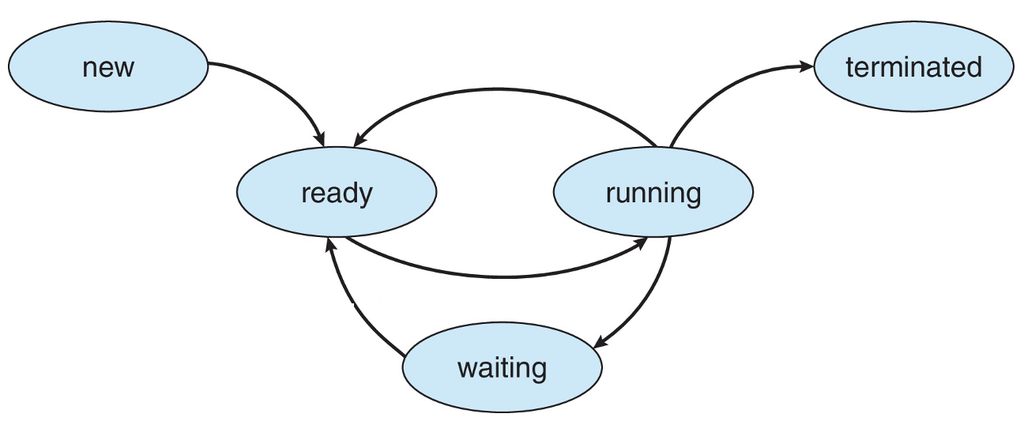

## Process state transitions (cont’d)

- Running process can move from running to terminated (exit or killed), moved to ready (time slice up), or blocked (signaled to wait, I/O)
- Which state transitions could happen with these expensive actions?
  - Compute a new RSA key?
  - Find the largest value in a 1TB of data?

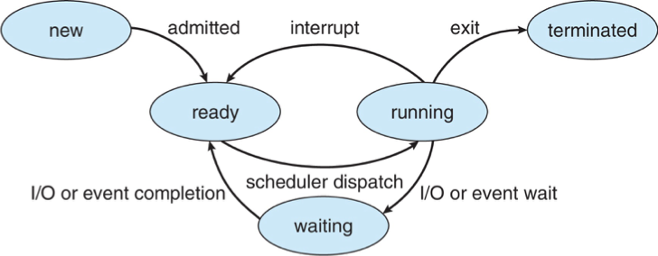

## State transition example

A running process calls `read()` on a file. **Trace its state transitions** from that moment until it gets its data back. What causes each transition?

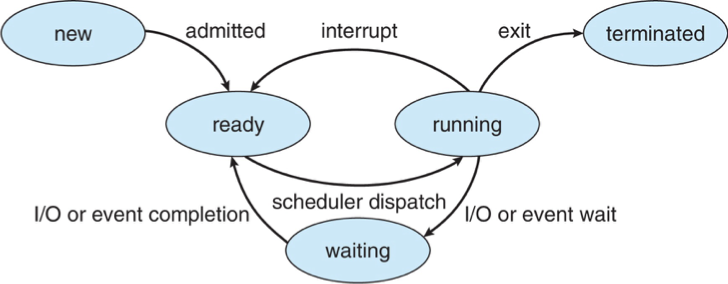

## Process scheduling

- OS process scheduler selects among available processes for next execution on CPU core
- Goal?
  - Maximize CPU use, quickly switch processes onto CPU core
- Maintains scheduling queues of processes
  - Ready queue: set of all processes residing in main memory, ready and waiting to execute
  - Wait queues: set of processes waiting for an event (i.e., I/O)
- Processes migrate among the various queues over their lifetime

## Context switching

- When CPU switches to another process, the system must save the state of the old process and load the saved state for the new process via a context switch
- Context of a process represented in the PCB
- Context-switch time is pure overhead; the system does no useful work while switching
  - The more complex the OS and the PCB → the longer the context switch
- Time dependent on hardware support
  - Some hardware provides multiple sets of registers per CPU → multiple contexts loaded at once

## Context switching overhead

- On the order of microseconds on modern hardware, used to be milliseconds
- If not done intelligently, you can spend more time context-switching than actual processing
- Question: Why shouldn’t processes control context switching?

## Scheduling basics

- Scheduler usually makes the transition decisions; hides the details from the process/user
- Processes often characterized as one of two types by what state they spend most of their time in
  - I/O bound: work is dependent on I/O; e.g., browser, db, media streaming
  - CPU bound: work is dependent on CPU; e.g., scientific apps, cryptography
  - Why does this matter?
    - Understanding which your process is allows for optimization
      - CPU-bound? Faster CPU, parallelize.
      - I/O? Faster I/O devices, use async
- Scheduler must balance CPU- & I/O-bound processes

What isn’t clear?

Comments? Thoughts?